# Prior Sensitivity Analysis

Julian Frattini

2026-09-25

This document demonstrates a prior sensitivity analysis, which shows how sensitive the posterior is to the chosen priors.

## Preparation

We investigate the simplest effect between two normally distributed variables $x$ and $y$. To investigate the questions, we simulate a simple dataset, where the target effect to estimate is `beta`.

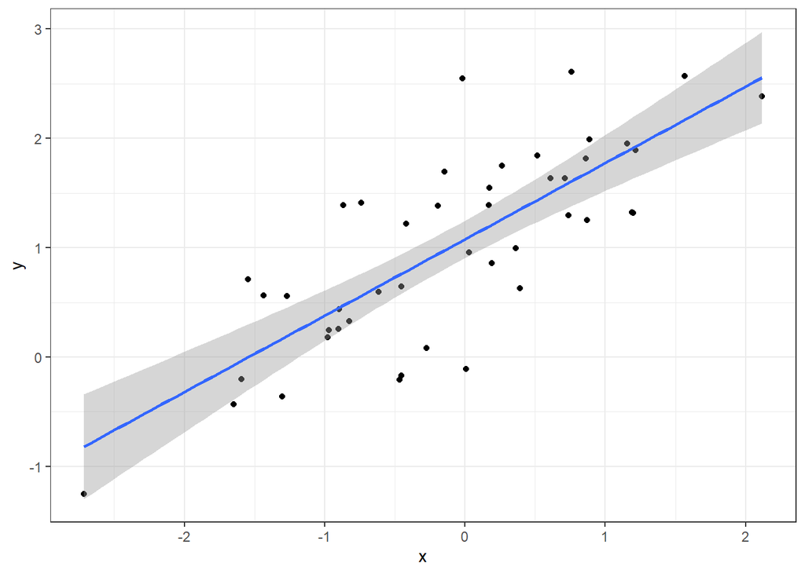

```r
n <- 45
beta <- 0.7

d1 <- data.frame(x = rnorm(n, 0, 1)) %>%
  mutate(y = rnorm(n, 1 + beta*x, 0.5))

ggplot(d1, aes(x = x, y = y)) +
  geom_point() +
  geom_smooth(formula = 'y ~ x', method = 'lm') +
  theme_bw()
```

We can train a simple model with arbitrary prior and posterior values.

```r
f1 <- bf(y ~ 1 + x)

priors1 <- c(
  prior(normal(0, 1), class = Intercept),
  prior(normal(0, 1), class = b),
  prior(exponential(1), class = sigma)
)

m1 <-
  brm(
    f1, data = d1, family = gaussian, prior = priors1,
    iter = 2000, warmup = 1000, chains = 4, cores = 4,
    file = "../../fits/m.sensitivity1", file_refit = "on_change"
  )
```

[output not shown]

[output not shown]

[output not shown]

[output not shown]

```r
summary(m1)
```

```
##  Family: gaussian
##   Links: mu = identity
## Formula: y ~ 1 + x
##    Data: d1 (Number of observations: 45)
##   Draws: 4 chains, each with iter = 2000; warmup = 1000; thin = 1;
##          total post-warmup draws = 4000
##
## Regression Coefficients:
##           Estimate Est.Error l-95% CI u-95% CI Rhat Bulk_ESS Tail_ESS
## Intercept     1.07      0.09     0.90     1.24 1.00     3254     2484
## x             0.69      0.09     0.52     0.86 1.00     3758     2483
##
## Further Distributional Parameters:
##       Estimate Est.Error l-95% CI u-95% CI Rhat Bulk_ESS Tail_ESS
## sigma     0.58      0.06     0.47     0.72 1.00     3265     2910
##
## Draws were sampled using sampling(NUTS). For each parameter, Bulk_ESS
## and Tail_ESS are effective sample size measures, and Rhat is the potential
## scale reduction factor on split chains (at convergence, Rhat = 1).
```

## Sensitivity Analysis

The idea is to pick a prior hyperparameter $\gamma$ to perturb, refit the model across a range of $\gamma$ values, and track how a posterior quantity of interest $\delta$ - the effect of $x$ on $y$ - responds. If $\delta$ barely moves as $\gamma$ varies over a reasonable range, the conclusion is robust to prior specification. If it swings a lot, the conclusion is prior-driven rather than data-driven.

In the simple model, the natural $\gamma$ to perturb is the width of the prior on `b_x`. $\delta$ is the posterior estimate of `b_x`.

```r
make_priors <- function(gamma) {
  c(
    prior(normal(0, 1), class = Intercept),
    set_prior(paste0("normal(0,", gamma, ")"), class = "b"),
    prior(exponential(1), class = sigma)
  )
}
```

Re-fit the model for several different values of $\gamma$ and cache them individually.

```r
gammas <- c(0.1, 0.25, 0.5, 1, 2, 5)

fits <- purrr::map(gammas, function(g) {
  brm(
    f1, data = d1, family = gaussian, prior = make_priors(g),
    iter = 2000, warmup = 1000, chains = 4, cores = 4,
    file = paste0("../../fits/m.sensitivity1_g", g),
    file_refit = "on_change"
  )
})
```

[output not shown]

[output not shown]

[output not shown]

[output not shown]

[output not shown]

[output not shown]

[output not shown]

[output not shown]

[output not shown]

[output not shown]

[output not shown]

[output not shown]

[output not shown]

[output not shown]

[output not shown]

[output not shown]

[output not shown]

[output not shown]

[output not shown]

[output not shown]

[output not shown]

[output not shown]

[output not shown]

[output not shown]

Now, extract the posterior estimate $\delta$ for each value of $\gamma$.

```r
sensitivity_results <- purrr::map2_dfr(gammas, fits, function(g, fit) {
  fixef(fit)["x", ] %>%
    as.list() %>%
    as_tibble() %>%
    mutate(gamma = g)
})

sensitivity_results
```

```
## # A tibble: 6 × 5
##   Estimate Est.Error  Q2.5 Q97.5 gamma
##      <dbl>     <dbl> <dbl> <dbl> <dbl>
## 1    0.342    0.0848 0.168 0.501  0.1
## 2    0.621    0.0841 0.450 0.781  0.25
## 3    0.679    0.0859 0.511 0.848  0.5
## 4    0.693    0.0885 0.513 0.873  1
## 5    0.695    0.0861 0.522 0.859  2
## 6    0.698    0.0876 0.527 0.870  5
```

Visualize the sensitivity of the effect across the different values of $\gamma$.

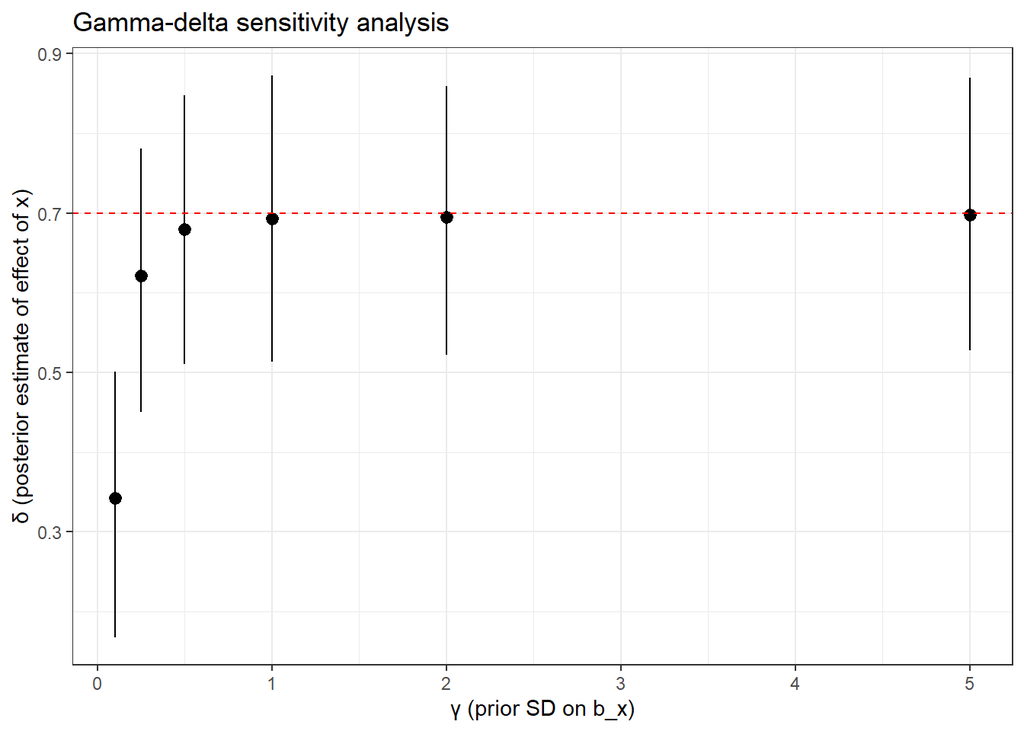

```r
ggplot(sensitivity_results, aes(x = gamma, y = Estimate)) +
  geom_pointrange(aes(ymin = Q2.5, ymax = Q97.5)) +
  #scale_x_log10() +
  geom_hline(yintercept = beta, linetype = "dashed", color = "red") +
  labs(
    x = "γ (prior SD on b_x)",
    y = "δ (posterior estimate of effect of x)",
    title = "Gamma-delta sensitivity analysis"
  ) +
  theme_bw()
```

This means that the effect of $x$ on $y$ is robust to prior choice, provided the prior SD is at least around 0.5. Below that threshold, the conclusion is prior-driven rather than data-driven. Above that threshold, the data speak for themselves, and reporting normal(0,1) for the prior is safely in the “plateau” region.

A transition zone at very tight priors followed by a flat plateau is the hoped-for result. If the whole curve had been sloped rather than flattening out, that would signal that even the original prior was still exerting meaningful influence.